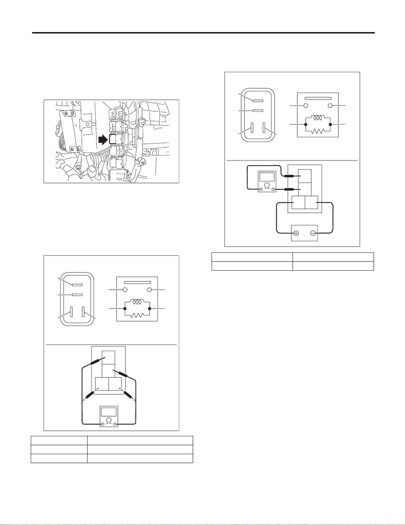

FU(STI)-57

Main Relay

FUEL INJECTION (FUEL SYSTEMS)

20.Main Relay

A: REMOVAL

1) Disconnect the ground cable from battery.

2) Remove the glove box. <Ref. to EI-63, REMOV-

AL, Glove Box.>

3) Remove the main relay from relay block.

B: INSTALLATION

Install in the reverse order of removal.

C: INSPECTION

1) Check that the main relay has no deformation,

cracks or other damages.

2) Measure the resistance between main relay ter-

minals.

3) Connect battery positive terminal to terminal No.

3 and battery ground terminal to terminal No. 4, and

measure the resistance between the main relay ter-

minals.

Terminal No. Standard

1 and 2 1 MΩ or more

3 and 4 130.4 — 230.8 Ω (when 20°C (68°F))

FU-08335

IN-02836

Terminal No. Standard

1 and 2 Less than 1 Ω

FU-04077